# Transposable Elements (TEs) analysis in E12.5 placentae from OgtY841A-het Females x OgtY841A-homo males

# 3 DE-Seq analysis of RNA transposons

I include the FPKM of DNA transposons as confounding factor in DESeq2 formula.

Before running the Differential Expression analysis, the data are pre-filtered to remove all repetitive elements with < 10 reads among all samples.

## 3.1 Differentially expressed TEs

```
## log2 fold change (MMSE): condition M_HEMI vs M_WT
## Wald test p-value: condition M_HEMI vs M_WT
## DataFrame with 4 rows and 5 columns
##             baseMean log2FoldChange     lfcSE      pvalue      padj
##            <numeric>      <numeric> <numeric>   <numeric> <numeric>
## IAPLTR2_Mm   179.523       0.316178 0.1519884 0.000104618 0.0101654
## MERVL-int    527.511       0.258159 0.0914886 0.000145426 0.0110614
## L1MdTf_II    393.994       0.286710 0.1144614 0.000151786 0.0110614
## L1MdTf_I     401.114       0.280728 0.1140062 0.000176763 0.0114503
```

## 3.2 MA-plots

- The threshold used for a dot to be coloured in the MA-plots is p-value adjusted < 0.05.
- Transposable elements whose mean expression > 20 and abs(log2FoldChange) > 0.2 are labeled.

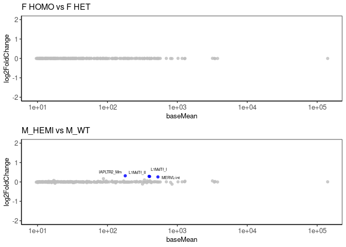

## 3.3 FPKM of differentially expressed TEs

I also include two non-DE TEs, one expressed and one non-expressed in murine trophoblast cells (Ext.Fig3g in [Weigert et al. 2023](https://www.nature.com/articles/s41556-023-01114-y) ).

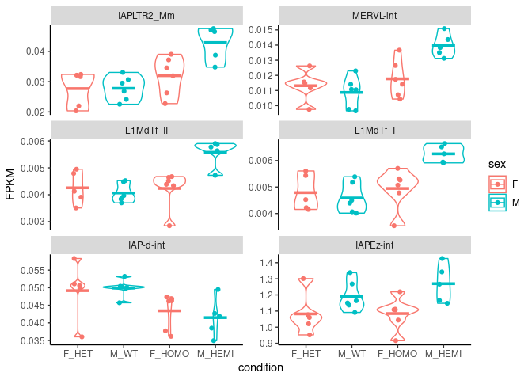